# Metabolomics!

Pietro Franceschi | pietro.franceschi@fmach.it

## What is Metabolomics

The objective of metabolomics is to characterize in the most complete and comprehensive way the pool of small molecules which are the end product of the metabolism.

The pool of these molecules is known as metabolome.

Metabolomics aims at measuring the metabolites in a quantitative way and to characterize their relations and associations.

## Why Metabolomics

1. For the quest of molecular markers (*e.g. nutrition, health, cancer* )
2. To perform molecular phenotyping (*e.g. personalized medicine*)
3. To associate a genes to its function (*e.g. to support breeding*)
4. To study the chemical interaction in complex systems (*e.g. ecological interaction are often mediated by chemicals*)

## Challenges of Metabolomics

1. Size of the chemical space: the metabolome is extremely diverse, in particular for plants and microorganisms.
2. Diversity in the chemical properties: different molecules would require different methods of analysis.
3. Huge differences in concentration: abundant metabolites and relevant traces should be seen at the same time.
4. Coverage: no single analytical method is able to analyze everything.
5. Pre-analytics: the approach is so sensitive that every non-reproducible pre-analytical step will affect the data.

# Doing Metabolomics

## Targeted

We use the analytical method of choice to analyze a selected set of metabolites. The list can go from around 10 to something around 500.

The measured variables are metabolites

⚠️ **Warning:** The numbers we collect is the concentration of the individual metabolites.

## Untargeted

We “throw” a raw sample in our instrument, trying to analyze as much signals as possible. How many things we are able to see is unknown.

The measured variables are **not** metabolites

⚠️ **Warning:** The numbers we get are the peak areas of the individual features.

## Why targeted, why untargeted

### Targeted

1. 😀 quantitative results are obtained “by definition”
2. 😀 results can be interpreted under the light of the known metabolic pathways
3. 😀 the analytical results are comparable across experiments and across laboratories (aka limited *batch effect*)
4. 😞 we basically look only to the expected

### Untargeted

1. 😀 holistic
2. 😀 open to unexpected
3. 😞 tricky
4. 😞 hardly quantitative
5. 😞 not standardized

## The ideal Metabolomics road-map

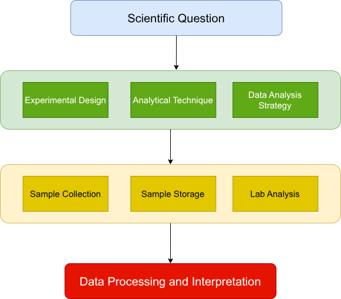

# Analytical Techniques in Metabolomics

## How Metabolomics

We need an analytic technique:

1. Sensitive to the **chemical structure**.
2. **Universal** - able to see almost all classes of molecules.
3. **Sensitive** - able to see metabolites with low concentrations.
4. With an high **dynamic range** - able to measure at the same time low and high abundant compounds.

## Nuclear Magnetic Resonance

[figure not shown]

## Molecules and Peaks

[figure not shown]

## Mass Spectrometry

[figure not shown]

## Molecules and Ions

[figure not shown]

## Chromatographic Separation

[figure not shown]

## Molecules and features

[figure not shown]

## Molecules and features

In all the techniques presented so far, each metabolite give rise to a large set of different signals:

- **MS** - the different ions produced in the ionization of the metabolite.
- **NMR** - the different peaks coming from the resonance of the nuclei present in the molecule.
- **LC/GC-MS** - the different ions which are eluting at different time. These mz/rt couples are called *features*

⚠️ **Warning:** All the variables coming from the same molecule are highly correlated.

## Sources of Analytical Variability

### 1 - The measurement itself

Even with the perfect instrument the “numbers” will change. Try measuring your temperature 10 times in a row ;-)

### 2 - Chromatographic drifts

When chromatographic separation is present, elution times will slightly change from run to run. For GC the situation is better, but far from being perfect

## Sources of Analytical Variability

### 3 - Matrix effects

In metabolomics we are loading on the instruments a complex mixture of chemicals. This complex chemical environment will affect the *response* of the molecules in an often unpredictable way. The importance of this effect is so strong in MS that this technique is almost always coupled with chromatography

With chromatography the different molecules reach the ionization source at different times, reducing the matrix effect.

### 4 - Sample handling

The approach is so powerful that all aspect related to sample handling/storage/extraction will affect the final result

## NMR vs LC/GC MS

### NMR

1. 😀 Reproducible
2. 😀 Inherently quantitative
3. 😀 Sensitive to the chemical structure
4. 😞 Relatively insensitive
5. 😞 Dynamic range

### LC/GC - MS

1. 😀 Sensitive
2. 😀 Universal
3. 😀 With high dynamic range
4. 😞 Less reproducible (😉)

# Pitfalls and caveats

## Poor planning

*Aka … I have a refrigerator of samples … shall we give a look?*

1. Unclear scientific question
2. Suboptimal experimental design (no replicates, no proper definition of the study factors)
3. Erratic analytical planning (unreliable sample extraction, disorganized analytical runs)
4. …

Remember that instruments are sensitive, so errors will unavoidably show up in the final data (*garbage in, garbage out*)

## Sampling and sample handling

- The analytical techniques used in metabolomics are extremely sensitive
- More often than not the samples are complex mixtures of chemicals
- Poor preparation, handling and storage will hamper the overall investigation

*e.g. how to sample in a representative way in GC? How to quench the metabolism of microorganisms? How to store biofluids?*

## Annotation …

[figure not shown]

## Annotation in Untargeted Metabolomics

- We do not measure the concentration of metabolites
- Knowing the metabolite, it is much easier to predict the signals we actually measure (ions, NMR peaks, features)
- … the reverse (called annotation) is not at all trivial

Chemical annotation is the current bottleneck in untargeted metabolomics

## Annotation strategies

- Fragmentation experiments (in MS!)
- In house db of standards
- On-line db of standards
- Chemoinformatics
- Molecular Networks
- ML/AI (prediction of chemical structures from spectra)

## Statistical Validation

1. Unfavorable variables-to-samples ratio
2. Unexpected subpopulations
3. Not always easy to place the results inside the established body of knowledge

Two-stage design: 1. hypothesis generation → 2. validation

## Domain Specific Validation

Are my results fitting inside the established (domain specific) body of knowledge?

*e.g. Are my markers reasonable under the light of the human metabolism?*

## Key Elements to design a successful metabolomics investigation

1. **Planning**
   - Scientific question
   - Experimental design
   - Analytical platform and analytical run
   - Data analysis strategy
2. **Awareness**
   - *The strength of the chain is in the weakest link*
3. **Interdisciplinarity**
   - The analyst and/or the data analyst are your best friends …